# Bitcoin Price Time Series Analysis

## Overview

In this project, we examine the price history of bitcoin (BTC) across various frequencies (daily, weekly, and monthly) and conduct tests for time series stationarity. One key observation is that all of the price series exhibit significant autocorrelation, which is consistent with a time series being non-stationary. It is then demonstrated that transforming the price series into a return series (by differencing the natural logarithm of prices) resolves much of this autocorrelation and is a more appropriate measurement for conducting statistical analysis in asset pricing (e.g. CAPM, FF, etc).

Next, we’ll explore the time series decomposition of the price series and practice with some R packages geared towards time series analysis. These include the xts package, tseries package, and seasonal package. With seasonality, there are a few options to consider. First is day-of-week seasonality where we don’t find much of significant results. A more common approach to modeling seasonality is with month-of-year seasonality. Here, we find some marginal evidence that October tends to outperform September in regard to BTC price appreciation.

Lastly, we’ll explore another aspect of seasonality around the four-year halving cycle for Bitcoin. Given that there are still only a couple full cycles that have been completed since BTC price data begins, these are still in their infancy regarding any statistical conclusions.

## R Packages

- The [devtools package](https://cran.r-project.org/package=devtools) contains the `install_github()` function, which allows us to install packages directly from GitHub. This will let us install the geckor package, which is no longer published to CRAN.
- The [geckor package](https://github.com/next-game-solutions/geckor) is a wrapper for the [CoinGecko API](https://www.coingecko.com/en/api) and allows for easy import of bitcoin price data.
- The [xts package](https://cran.r-project.org/package=xts) is short for ‘eXtensible Time Series’, which contains tools for working with time series data.
- The [ggplot2 package](https://cran.r-project.org/package=ggplot2) for graphics and visuals.
- The [tseries package](https://cran.r-project.org/package=tseries) contains additional time series analysis functions that we will explore.
- The [seasonal package](https://cran.r-project.org/package=seasonal) contains an interface to the [Census X-13-ARIMA-SEATS model](https://www.census.gov/data/software/x13as.html).
- The [seasonalview package](https://cran.r-project.org/package=seasonalview) brings a graphical user interface to that Census model.
- The [rmarkdown package](https://cran.r-project.org/package=rmarkdown) is used to generate this R Notebook.

```r
# Create list of packages needed for this exercise, omit geckor since its not on CRAN
list.of.packages = c("devtools","xts","ggplot2","tseries","seasonal","seasonalview","rmarkdown")
# Check if any have not yet been installed
new.packages = list.of.packages[!(list.of.packages %in% installed.packages()[,"Package"])]
# If any need to be installed, install them
if(length(new.packages)) install.packages(new.packages)
# Since geckor is no longer published to CRAN, install via GitHub
library(devtools)
devtools::install_github("next-game-solutions/geckor")
```

```r
# Load in the remaining packages
library(geckor)
library(xts)
library(tseries)
library(ggplot2)
library(seasonal)
library(seasonalview)
```

## Bitcoin Data Import

To import bitcoin prices, we will use the geckor R package, which utilizes the CoinGecko API.

```r
BTCraw = coin_history_range(coin_id="bitcoin",
                            vs_currency = "usd",
                            from = as.POSIXct("2013-04-27"),
                            to = as.POSIXct(Sys.Date()))
```

```
Warning: Missing values found in column(s)
• market_cap
```

Interestingly, as of May 2023, the above import code produces a warning of some missing values in the market_cap column. If we more closely examine (use `which()` and `is.na()` to identify the row numbers of the missing values), these missing values appear to be for April 2, 2017. Not sure why exactly this is, but since we have price data on each of those days, we can impute these values without too much difficulty.

```r
# Identify indices of missing values
missinginds = which(is.na(BTCraw$market_cap))
BTCraw[missinginds,]
```

| timestamp | coin_id | vs_currency | price | total_volume | market_cap |
| --- | --- | --- | --- | --- | --- |
| 2017-04-02 | bitcoin | usd | 1098.068 | 80231506 | NA |

```r
for (i in missinginds){
  # Subset data to 3-day period from [-1,1]
  subprice = BTCraw[(i-1):(i+1),]
  # Create ncoins variable by dividing market cap by price
  subprice$ncoins = subprice$market_cap/subprice$price
  # Impute missing value with average of day before and day after
  subprice$ncoins[2] = (subprice$ncoins[1]+subprice$ncoins[3])/2
  # Compute missing market cap as price*ncoins
  subprice$market_cap[2] = subprice$ncoins[2]*subprice$price[2]
  # Move imputed value back to main data frame
  BTCraw$market_cap[i] = subprice$market_cap[2]
}
sum(is.na(BTCraw)) # Verify no more missing values
```

```
[1] 0
```

Then reformat the timestamp to a date variable:

```r
BTCraw$Date = as.POSIXct(BTCraw$timestamp)
```

To better make use of the ordered nature of time series data like this, we take the OHLC data and save it as an `xts` object. In the new `BTCdaily` variable, the rows are indexed by the date variable, which enables some additional functionality over a standard data frame.

```r
BTCdaily = xts(BTCraw$price,order.by=BTCraw$Date)
```

Then as one point of comparison, we will examine various frequencies for the price series. The `xts` package allows us to easily convert the daily price data into weekly or monthly OHLC series.

```r
BTCweeksOHLC = to.weekly(BTCdaily, drop.time=TRUE)
BTCweeks = BTCweeksOHLC$BTCdaily.Close
BTCmonthOHLC = to.monthly(BTCdaily, drop.time=TRUE)
BTCmonth = BTCmonthOHLC$BTCdaily.Close
```

## Exploring the Full Bitcoin Price Series

### Basic Price Charts

We’ll start with some simple plots of the BTC price series that we downloaded. Starting with the daily chart, then weekly and monthly.

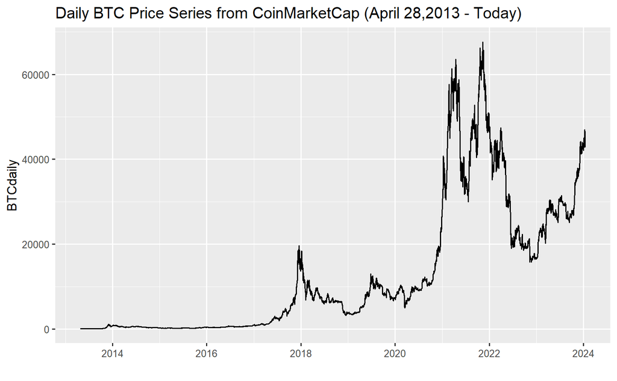

```r
ggplot() +
  geom_line(aes(x=index(BTCdaily),y=BTCdaily)) +
  xlab("") +
  ggtitle("Daily BTC Price Series from CoinMarketCap (April 28,2013 - Today)")
```

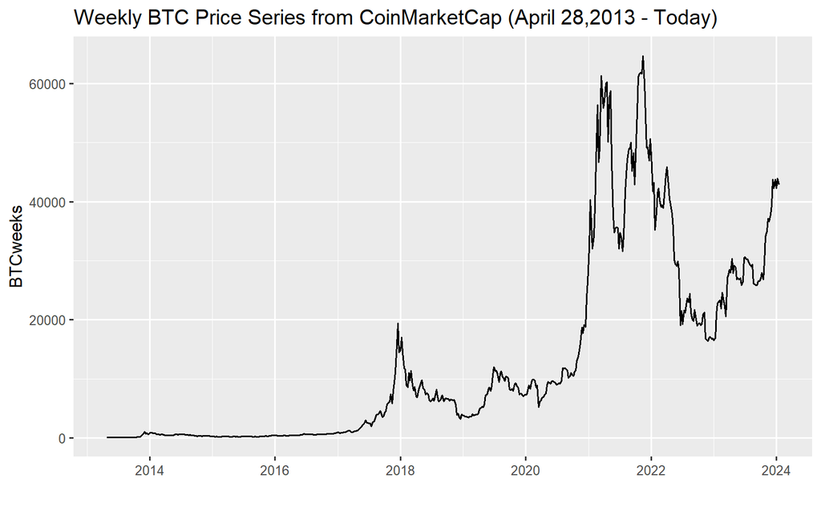

```r
ggplot() +
  geom_line(aes(x=index(BTCweeks),y=BTCweeks)) +
  xlab("") +
  ggtitle("Weekly BTC Price Series from CoinMarketCap (April 28,2013 - Today)")
```

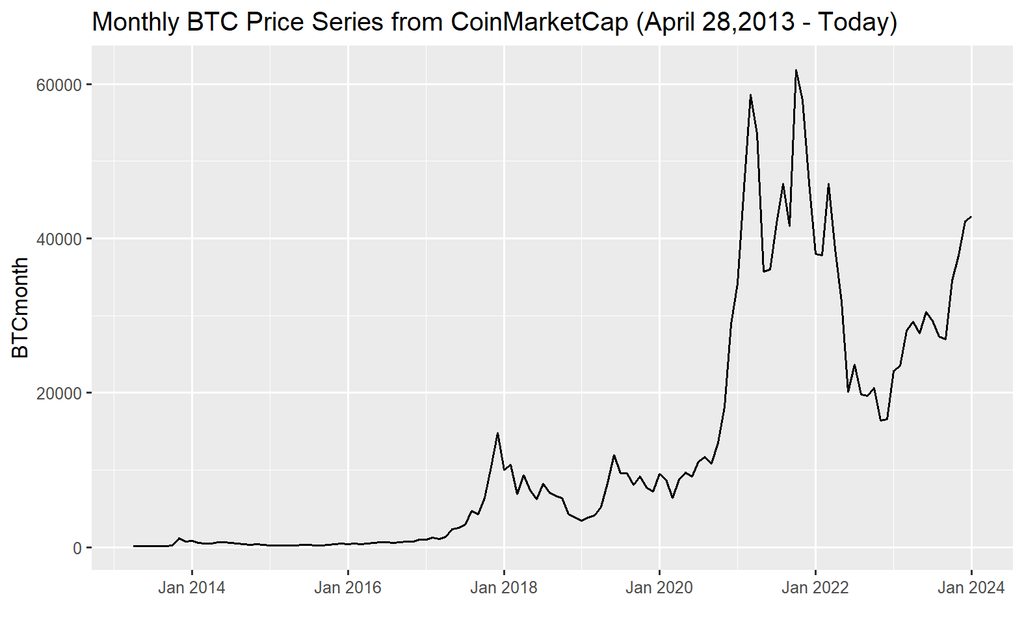

```r
ggplot() +
  geom_line(aes(x=index(BTCmonth),y=BTCmonth)) +
  xlab("") +
  ggtitle("Monthly BTC Price Series from CoinMarketCap (April 28,2013 - Today)")
```

### Log Price Charts

As detailed in other projects, a more appropriate way to analyze financial time series is to use rates of change (growth rates/returns) instead of levels (prices). The first step in calculating continuously compounded growth rates is to take the natural logarithm of the prices. There are two approaches for plotting out the logged price charts. The first approach is to simply compute the log(prices) and plot that series.

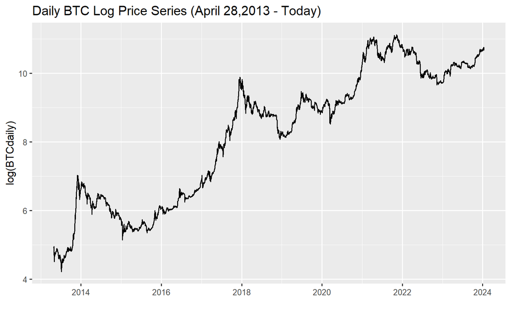

```r
ggplot() +
  geom_line(aes(x=index(BTCdaily), y=log(BTCdaily))) +
  xlab("") +
  ggtitle("Daily BTC Log Price Series (April 28,2013 - Today)")
```

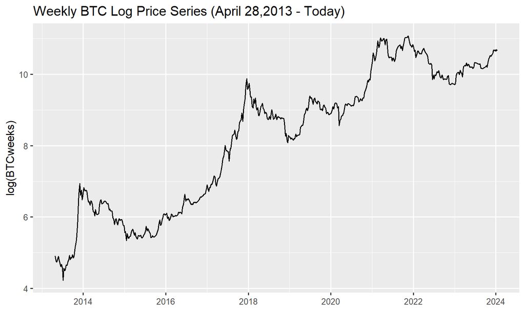

```r
ggplot() +
  geom_line(aes(x=index(BTCweeks), y=log(BTCweeks))) +
  xlab("") +
  ggtitle("Weekly BTC Log Price Series (April 28,2013 - Today)")
```

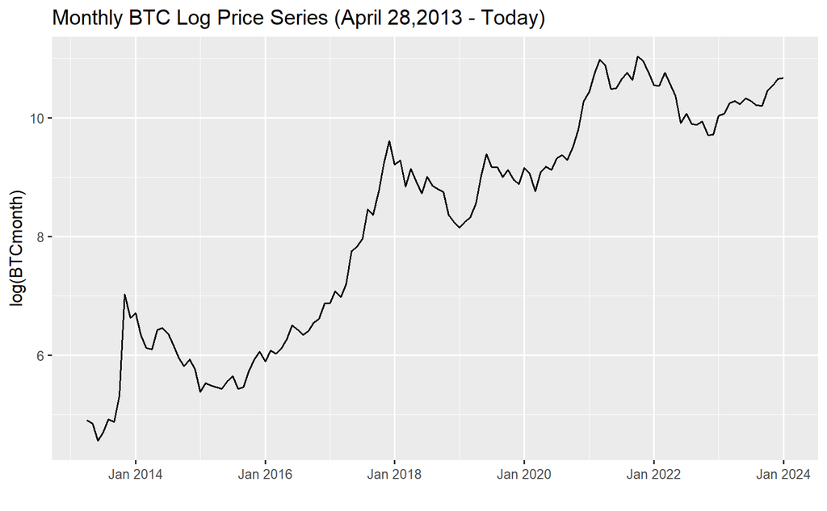

```r
ggplot() +
  geom_line(aes(x=index(BTCmonth), y=log(BTCmonth))) +
  xlab("") +
  ggtitle("Monthly BTC Log Price Series (April 28,2013 - Today)")
```

Alternatively, we can generate the same charts by instead plotting the non-logged price series with a logarithmic y-axis. This is done in `ggplot` with the `scale_y_continuous(trans='log10')` setting.

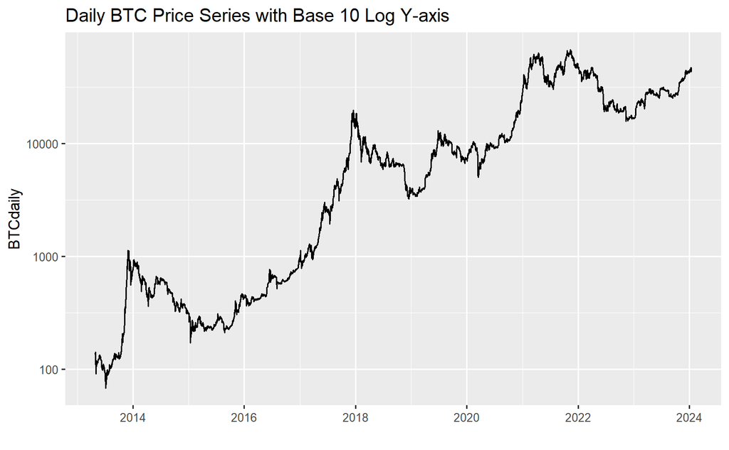

```r
ggplot() +
  geom_line(aes(x=index(BTCdaily), y=BTCdaily)) +
  scale_y_continuous(trans='log10') +
  xlab("") +
  ggtitle("Daily BTC Price Series with Base 10 Log Y-axis")
```

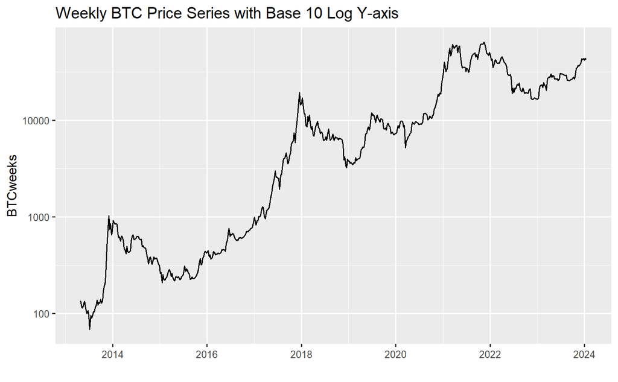

```r
ggplot() +
  geom_line(aes(x=index(BTCweeks), y=BTCweeks)) +
  scale_y_continuous(trans='log10') +
  xlab("") +
  ggtitle("Weekly BTC Price Series with Base 10 Log Y-axis")
```

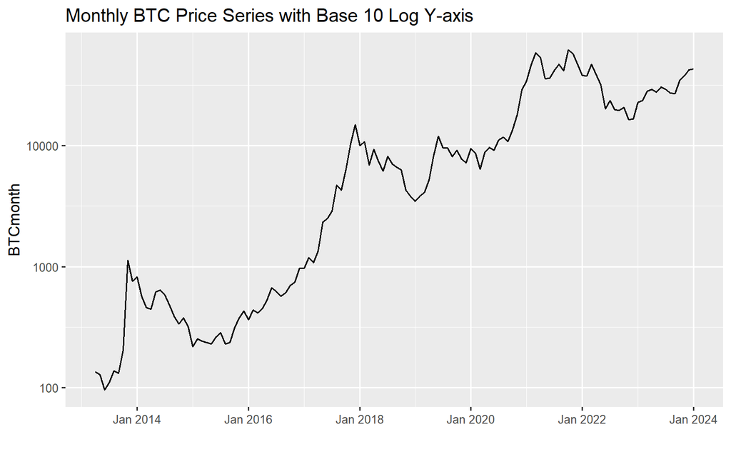

```r
ggplot() +
  geom_line(aes(x=index(BTCmonth), y=BTCmonth)) +
  scale_y_continuous(trans='log10') +
  xlab("") +
  ggtitle("Monthly BTC Price Series with Base 10 Log Y-axis")
```

### Log Return Charts

Lastly, we’ll finish the price to return conversion by differencing the log(prices). The steps for this involve converting the prices back to numeric variables (from xts) so that they can be logged, and then subtracting the `lag()` from each period to compute the log returns. Since these are all at various frequencies, the last three lines convert the returns to annualized returns in percentage units.

```r
# Create data frames with date column
rBTCdaily = data.frame(Date=index(BTCdaily))
rBTCweeks = data.frame(Date=index(BTCweeks))
rBTCmonth = data.frame(Date=index(BTCmonth))
# Compute log returns
rBTCdaily$Return = log(as.numeric(BTCdaily)) - log(as.numeric(lag(BTCdaily)))
rBTCweeks$Return = log(as.numeric(BTCweeks)) - log(as.numeric(lag(BTCweeks)))
rBTCmonth$Return = log(as.numeric(BTCmonth)) - log(as.numeric(lag(BTCmonth)))
# Annualize returns
rBTCdaily$AnnRet = rBTCdaily$Return*100*365
rBTCweeks$AnnRet = rBTCweeks$Return*100*52
rBTCmonth$AnnRet = rBTCmonth$Return*100*12
# Remove first row of each data frame (missing due to differencing)
rBTCdaily = rBTCdaily[-1,]
rBTCweeks = rBTCweeks[-1,]
rBTCmonth = rBTCmonth[-1,]
```

[figure not shown]

```r
ggplot(rBTCdaily,aes(x=Date,y=AnnRet))+
  geom_col()+
  xlab("") +
  ggtitle("BTC Annualized Daily Returns")
```

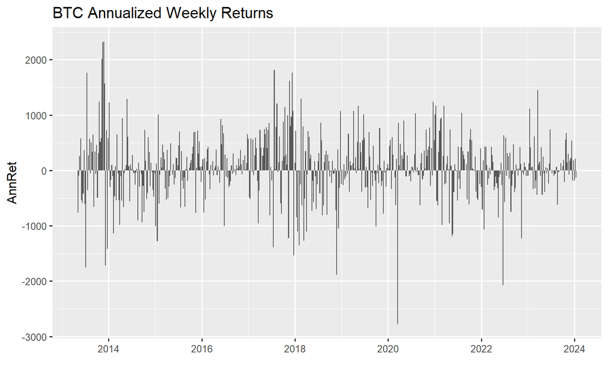

```r
ggplot(rBTCweeks,aes(x=Date,y=AnnRet))+
  geom_col()+
  xlab("") +
  ggtitle("BTC Annualized Weekly Returns")
```

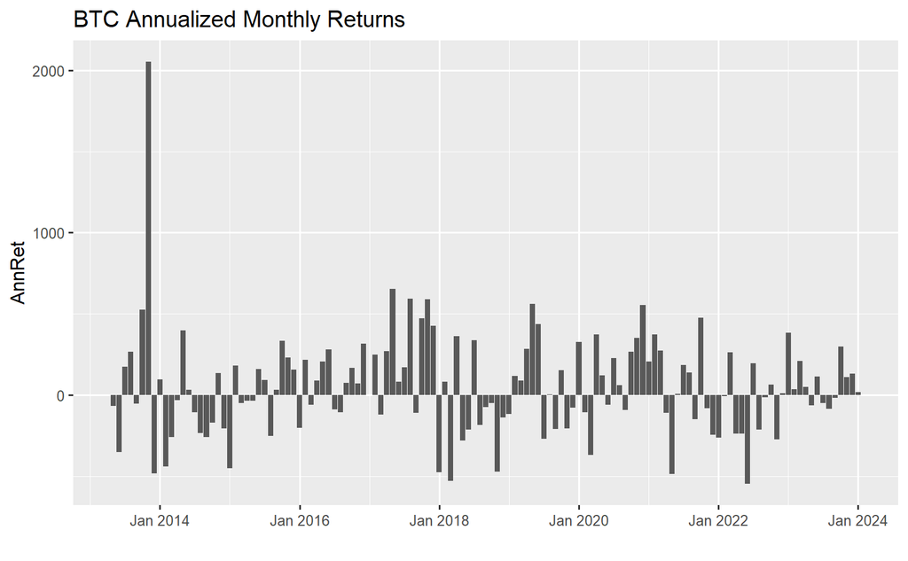

```r
ggplot(rBTCmonth,aes(x=Date,y=AnnRet))+
  geom_col()+
  xlab("") +
  ggtitle("BTC Annualized Monthly Returns")
```

### Summary Statistics

In summarizing the return series, we can compare across the various frequencies. Since we annualized each series for their respective frequencies, the means of each series represent the average annual return. Below are two ways of computing the means and displaying the results. The first creates a new data frame with the means and then displays that data frame with values rounded to two decimals. The second approach is more direct and computes each mean in a separate line, which is wrapped in the `round()` function. From these means, the daily return series produces the largest mean; however, the less frequent means are only slightly smaller within 0.5%.

```r
meanAnnRets = data.frame(BTCdaily=mean(rBTCdaily$AnnRet), BTCweeks=mean(rBTCweeks$AnnRet), BTCmonth=mean(rBTCmonth$AnnRet))
round(meanAnnRets,digits=2)
```

| BTCdaily | BTCweeks | BTCmonth |
| --- | --- | --- |
| 53.74 | 53.56 | 53.56 |

```r
round(mean(rBTCdaily$AnnRet), digits=2)
```

```
[1] 53.74
```

```r
round(mean(rBTCweeks$AnnRet), digits=2)
```

```
[1] 53.56
```

```r
round(mean(rBTCmonth$AnnRet), digits=2)
```

```
[1] 53.56
```

However, from the volatilities (as measured by standard deviation of the return series), we can see that the more frequent series exhibit substantially more volatility.

```r
meanRetVols = data.frame(BTCdaily=sd(rBTCdaily$AnnRet), BTCweeks=sd(rBTCweeks$AnnRet), BTCmonth=sd(rBTCmonth$AnnRet))
round(meanRetVols,digits=2)
```

| BTCdaily | BTCweeks | BTCmonth |
| --- | --- | --- |
| 1443.03 | 574.71 | 315.56 |

One way to visualize the empirical distribution summarized by the mean and standard deviation is to plot a frequency histogram of the return series overlayed with a normal bell curve transformed by the empirical mean and standard deviation. The below code chunk first selects a reasonable bin width (`bw`) for each frequency (trial and error to select), then saves a count of non-missing observations, and generates the plot described above.

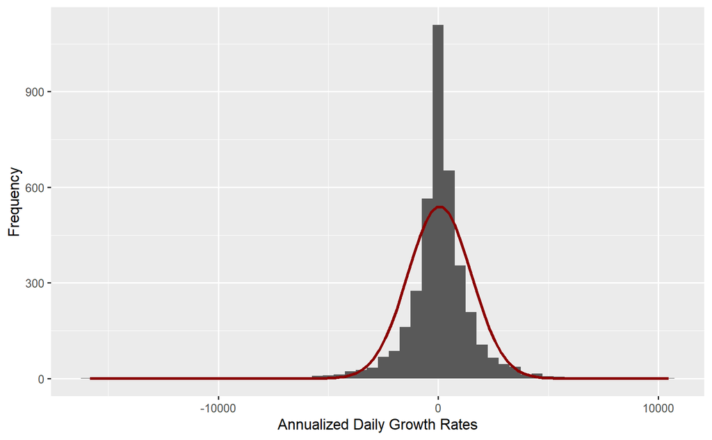

```r
# Set desired binwidth and number of non-missing obs
bw = 500
n_daily = sum(!is.na(rBTCdaily$AnnRet))
# Plot histogram of annualized returns and overlay graph of normal bell curve with same means and standard deviation
ggplot(rBTCdaily,aes(AnnRet)) +
  geom_histogram(binwidth=bw) +
  stat_function(fun=function(x) dnorm(x, mean=mean(rBTCdaily$AnnRet, na.rm=TRUE),   sd=sd(rBTCdaily$AnnRet, na.rm=TRUE)) * n_daily * bw, color="darkred", linewidth=1) +
  xlab("Annualized Daily Growth Rates") +
  ylab("Frequency")
```

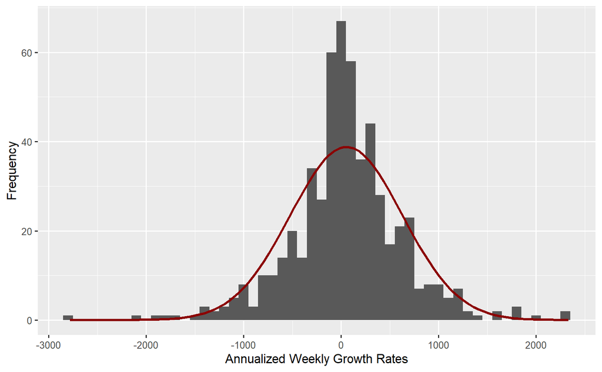

```r
bw = 100
n_weeks = sum(!is.na(rBTCweeks$AnnRet))
ggplot(rBTCweeks,aes(AnnRet)) +
  geom_histogram(binwidth=bw) +
  stat_function(fun=function(x) dnorm(x, mean=mean(rBTCweeks$AnnRet, na.rm=TRUE),   sd=sd(rBTCweeks$AnnRet, na.rm=TRUE)) * n_weeks * bw, color="darkred", linewidth=1) +
  xlab("Annualized Weekly Growth Rates") +
  ylab("Frequency")
```

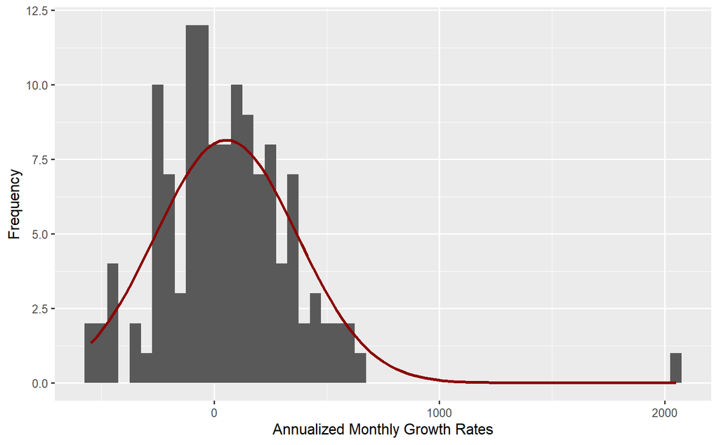

```r
bw = 50
n_month = sum(!is.na(rBTCmonth$AnnRet))
ggplot(rBTCmonth,aes(AnnRet)) +
  geom_histogram(binwidth=bw) +
  stat_function(fun=function(x) dnorm(x, mean=mean(rBTCmonth$AnnRet, na.rm=TRUE),   sd=sd(rBTCmonth$AnnRet, na.rm=TRUE)) * n_month * bw, color="darkred", linewidth=1) +
  xlab("Annualized Monthly Growth Rates") +
  ylab("Frequency")
```

The plots above show how the daily and weekly return series more closely resemble the fitted bell curves. However, they do tend to have more tail events than would be suggested by a normally distributed return series. The monthly series is skewed quite a bit by one early observation (November 2013) where the price rose from roughly $200 to over $1100, which converts to an annualized return of more than 2000.

## Time Series Stationarity, Autocorrelation, and the Dickey-Fuller Test

A [Stationary](https://en.wikipedia.org/wiki/Stationary_process) [Process](https://www.itl.nist.gov/div898/handbook/pmc/section4/pmc442.htm) is one that has a constant mean, variance, and autocorrelation structure over time. A [Non-Stationary Process](https://www.investopedia.com/articles/trading/07/stationary.asp) can have different aspects of non-stationarity, and financial variables often exhibit those types of trends. As we could visually see from the price and return plots, the prices had a clear upward trend over the long-run, whereas the return series exhibited ‘flatter’ dynamics. A more explicit way to visualize the autocorrelation structure of the time series is to examine its [autocorrelation function (ACF)](https://www.itl.nist.gov/div898/handbook/eda/section3/autocopl.htm). The ACF effectively measures the correlation between $e_t$ and $e_{t−1}$, and then for $e_t$ and $e_{t−2}$, and so on for as many lags as desired. In each frequency, the price series exhibits substantial autocorrelation, and the return series shows that much of it is resolved, although there still are a few lags that exceed the error bands.

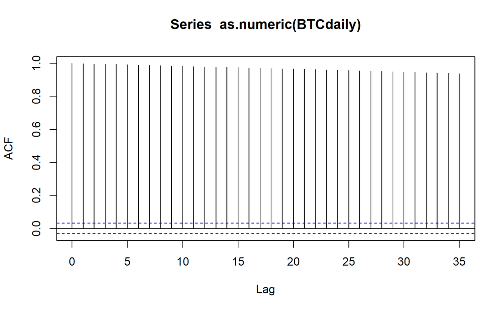

```r
acf(as.numeric(BTCdaily))
```

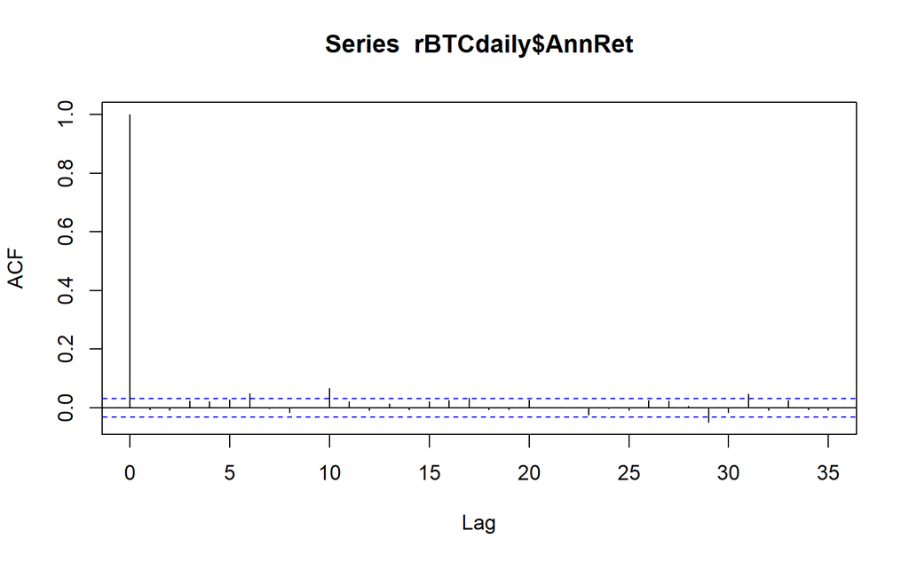

```r
acf(rBTCdaily$AnnRet)
```

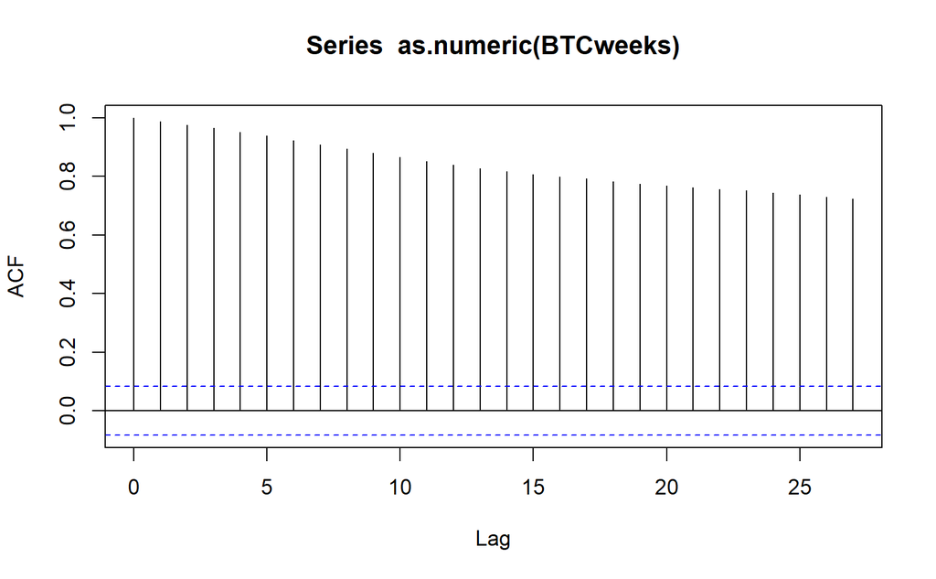

```r
acf(as.numeric(BTCweeks))
```

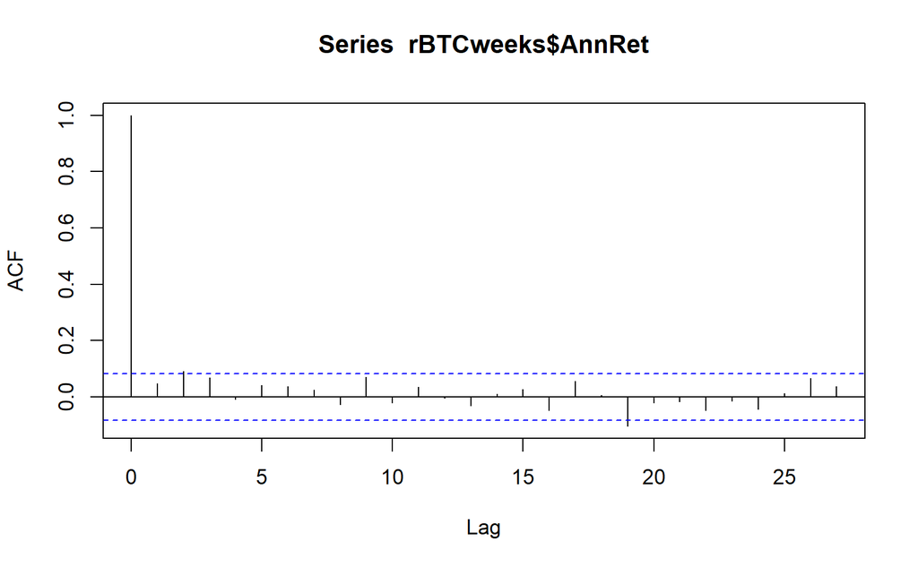

```r
acf(rBTCweeks$AnnRet)
```

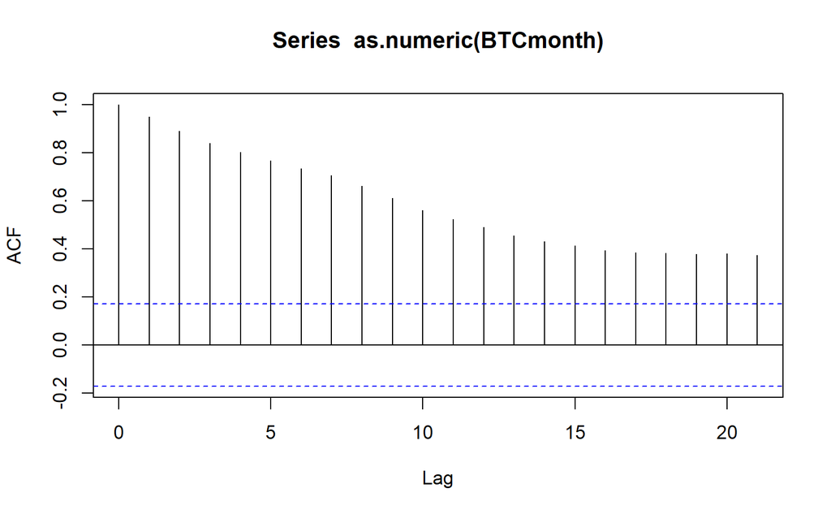

```r
acf(as.numeric(BTCmonth))
```

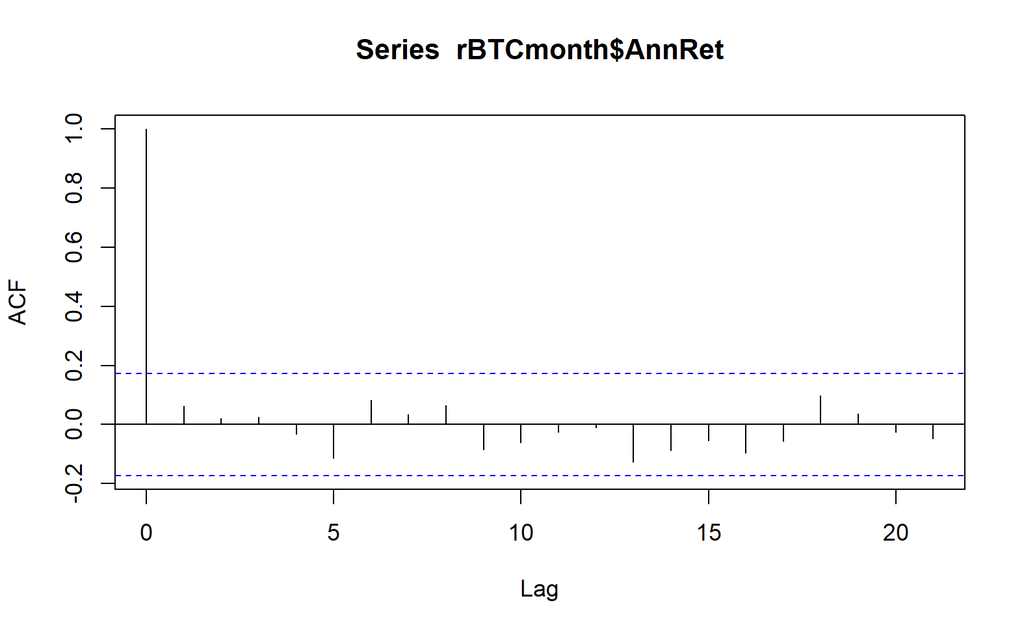

```r
acf(rBTCmonth$AnnRet)
```

The [partial autocorrelation function (PACF)](https://www.itl.nist.gov/div898/handbook/pmc/section4/pmc4463.htm) is similar to the ACF, except it produces the estimates of each lag after controlling for all shorter lags. In other words, rather than measuring the correlation between $e_t$ and $e_{t−2}$, we’d measure the linear regression coefficient for the second lag from a regression including both the first and second lags. A notable feature here from the price series is a very large (nearly 1) estimate, which follows from the large autocorrelation. Then subsequent lags often fall within the error bands, although some lags do exceed them. After converting to returns, the PACF’s have a much more condensed y-axis, which reflects the lower autocorrelation in the return series. Although, there certainly are still some lags that cross the error bands for the daily and weekly series.

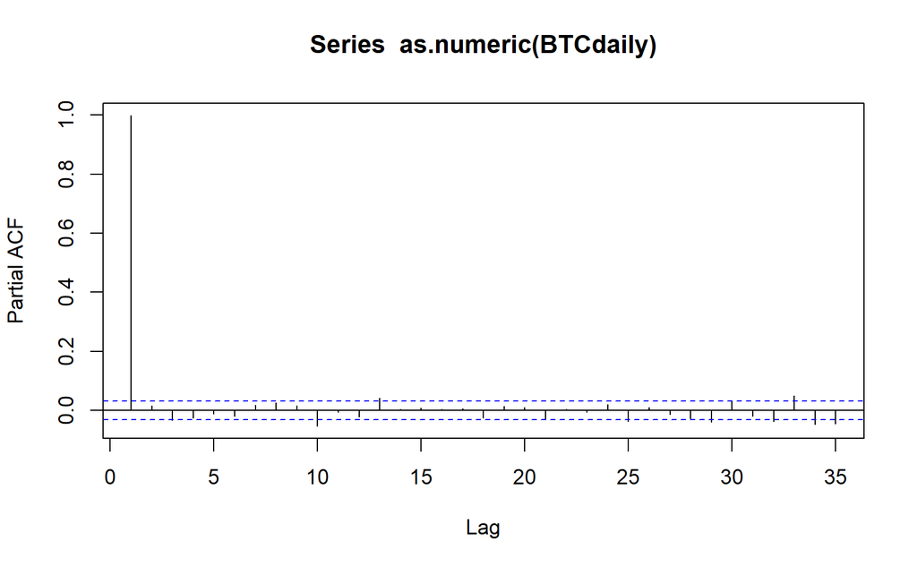

```r
pacf(as.numeric(BTCdaily))
```

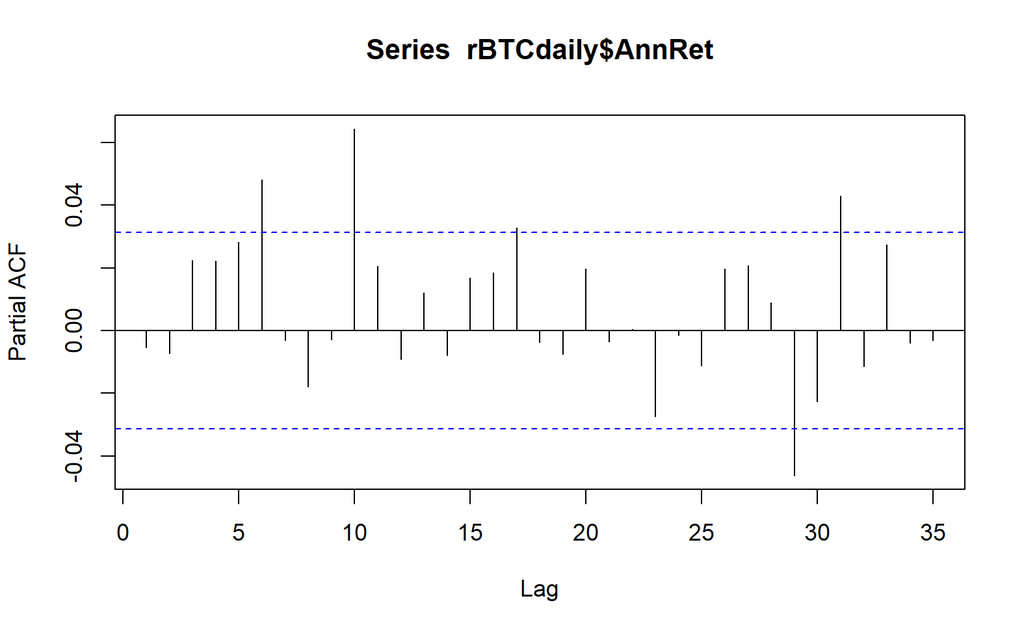

```r
pacf(rBTCdaily$AnnRet)
```

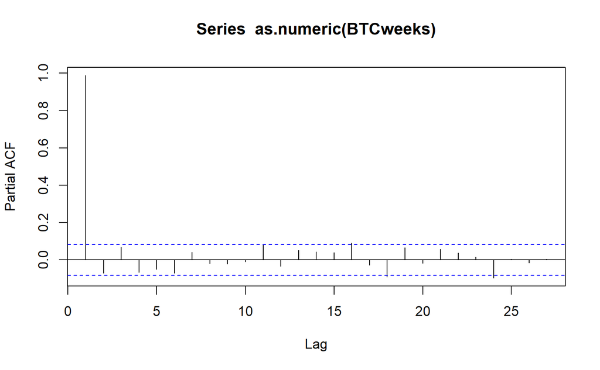

```r
pacf(as.numeric(BTCweeks))
```

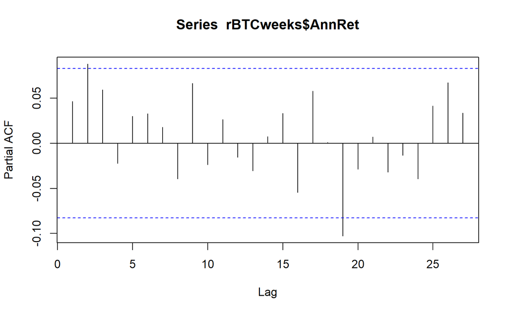

```r
pacf(rBTCweeks$AnnRet)
```

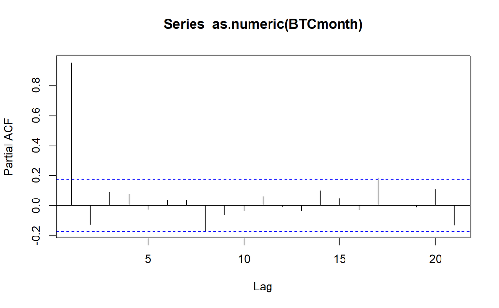

```r
pacf(as.numeric(BTCmonth))
```

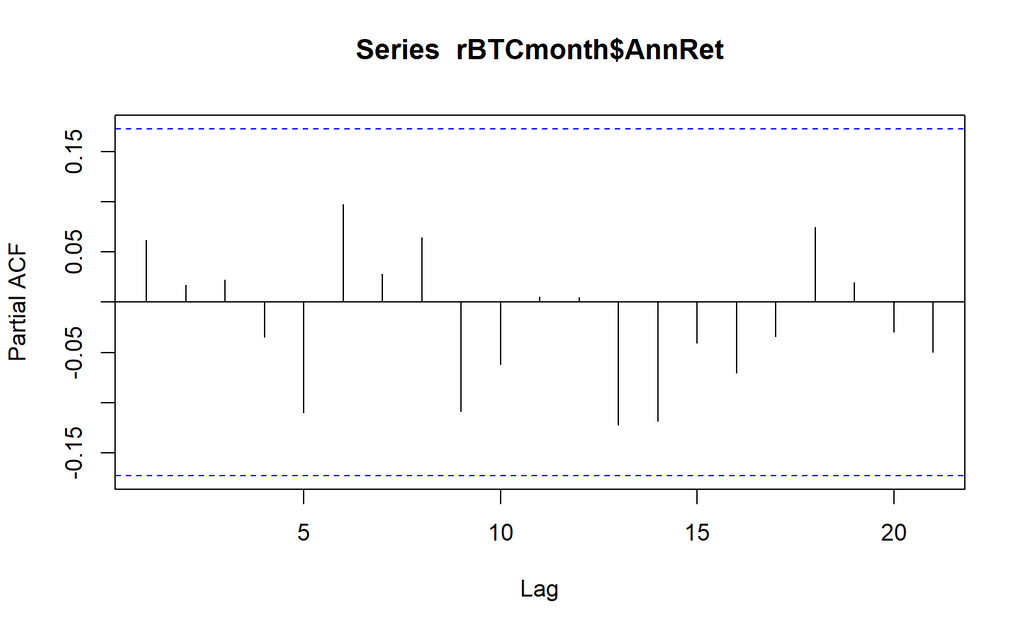

```r
pacf(rBTCmonth$AnnRet)
```

From the ACF and PACF, we can gather some visual evidence to support the suggestion that the price series suffers from autocorrelation (non-stationarity) and that the return series is stationary. To explicitly test for this, the [Augmented](https://en.wikipedia.org/wiki/Augmented_Dickey%E2%80%93Fuller_test) [Dickey-Fuller](https://www.rdocumentation.org/packages/aTSA/versions/3.1.2/topics/adf.test) [Test](https://cran.r-project.org/web/packages/tseries/tseries.pdf) allows us to construct a null hypothesis of non-stationarity, which implies that rejection of the null concludes stationarity. The `adf.test()` function comes from the `tseries` R package and generates the test statistic (Dickey-Fuller in the output) and p-value. We can see that the price series have smaller (in magnitude) test statistics that fail to reject the null, and then the return series produce larger (in magnitude) test statistics that reject the null and conclude that the return series are a stationary process.

```r
adf.test(as.numeric(BTCdaily))
```

```
    Augmented Dickey-Fuller Test

data:  as.numeric(BTCdaily)
Dickey-Fuller = -2.3365, Lag order = 15, p-value = 0.4358
alternative hypothesis: stationary
```

```r
adf.test(rBTCdaily$AnnRet)
```

```
    Augmented Dickey-Fuller Test

data:  rBTCdaily$AnnRet
Dickey-Fuller = -13.903, Lag order = 15, p-value = 0.01
alternative hypothesis: stationary
```

```r
adf.test(as.numeric(BTCweeks))
```

```
    Augmented Dickey-Fuller Test

data:  as.numeric(BTCweeks)
Dickey-Fuller = -3.1174, Lag order = 8, p-value = 0.1053
alternative hypothesis: stationary
```

```r
adf.test(rBTCweeks$AnnRet)
```

```
    Augmented Dickey-Fuller Test

data:  rBTCweeks$AnnRet
Dickey-Fuller = -6.9235, Lag order = 8, p-value = 0.01
alternative hypothesis: stationary
```

```r
adf.test(as.numeric(BTCmonth))
```

```
    Augmented Dickey-Fuller Test

data:  as.numeric(BTCmonth)
Dickey-Fuller = -2.4164, Lag order = 5, p-value = 0.4034
alternative hypothesis: stationary
```

```r
adf.test(rBTCmonth$AnnRet)
```

```
    Augmented Dickey-Fuller Test

data:  rBTCmonth$AnnRet
Dickey-Fuller = -4.3282, Lag order = 5, p-value = 0.01
alternative hypothesis: stationary
```

If you want to dig deeper into the theory and underlying assumptions behind these concepts, [Stationarity and Memory in Financial Markets](https://towardsdatascience.com/non-stationarity-and-memory-in-financial-markets-fcef1fe76053) has a nice discussion on the topic from a general context of financial markets.

## Seasonality

### Day-of-Week Seasonality

Another area of concern when it comes to stationarity of a time series is seasonality. For the time series that we have here, the first type of ‘season’ to check is day of the week for the daily series. One way to do this is to generate a count variable ($count=1,2,...,T$), and then calculate the remainder after dividing by 7. This [modulo operation](https://en.wikipedia.org/wiki/Modulo_operation) is done with `%%` in R. Then a quick test for seasonality is to regress the return series on a factor variable of the remainders. The `as.factor()` function will transform the numeric variable into a categorical variable with 7 categories.

```r
rBTCdaily$count = 1:length(rBTCdaily$AnnRet)
rBTCdaily$day = (rBTCdaily$count+2) %% 7
weekreg = lm(AnnRet~as.factor(day),data=rBTCdaily)
summary(weekreg)
```

```
Call:
lm(formula = AnnRet ~ as.factor(day), data = rBTCdaily)

Residuals:
     Min       1Q   Median       3Q      Max
-15772.5   -532.0      8.7    590.1  10366.0

Coefficients:
                Estimate Std. Error t value Pr(>|t|)
(Intercept)        2.005     61.021   0.033   0.9738
as.factor(day)1   70.873     86.335   0.821   0.4117
as.factor(day)2  146.025     86.335   1.691   0.0908 .
as.factor(day)3   31.464     86.296   0.365   0.7154
as.factor(day)4  111.156     86.296   1.288   0.1978
as.factor(day)5  -60.070     86.296  -0.696   0.4864
as.factor(day)6   62.875     86.296   0.729   0.4663
---
Signif. codes:  0 ‘***’ 0.001 ‘**’ 0.01 ‘*’ 0.05 ‘.’ 0.1 ‘ ’ 1

Residual standard error: 1443 on 3904 degrees of freedom
Multiple R-squared:  0.001956,  Adjusted R-squared:  0.0004217
F-statistic: 1.275 on 6 and 3904 DF,  p-value: 0.2652
```

In addition to testing for seasonality, we can also include the count variable as a linear time trend to see if returns are systematically changing over time. As seen below, this loads slightly negative and very insignificant.

```r
weekreg2 = lm(AnnRet~count+as.factor(day),data=rBTCdaily)
summary(weekreg2)
```

```
Call:
lm(formula = AnnRet ~ count + as.factor(day), data = rBTCdaily)

Residuals:
     Min       1Q   Median       3Q      Max
-15765.6   -527.1      5.8    592.1  10362.6

Coefficients:
                 Estimate Std. Error t value Pr(>|t|)
(Intercept)      26.39980   72.97312   0.362   0.7175
count            -0.01246    0.02044  -0.610   0.5421
as.factor(day)1  70.84235   86.34187   0.820   0.4120
as.factor(day)2 146.00641   86.34186   1.691   0.0909 .
as.factor(day)3  31.41431   86.30323   0.364   0.7159
as.factor(day)4 111.11874   86.30322   1.288   0.1980
as.factor(day)5 -60.09512   86.30320  -0.696   0.4863
as.factor(day)6  62.86243   86.30320   0.728   0.4664
---
Signif. codes:  0 ‘***’ 0.001 ‘**’ 0.01 ‘*’ 0.05 ‘.’ 0.1 ‘ ’ 1

Residual standard error: 1443 on 3903 degrees of freedom
Multiple R-squared:  0.002051,  Adjusted R-squared:  0.0002608
F-statistic: 1.146 on 7 and 3903 DF,  p-value: 0.3311
```

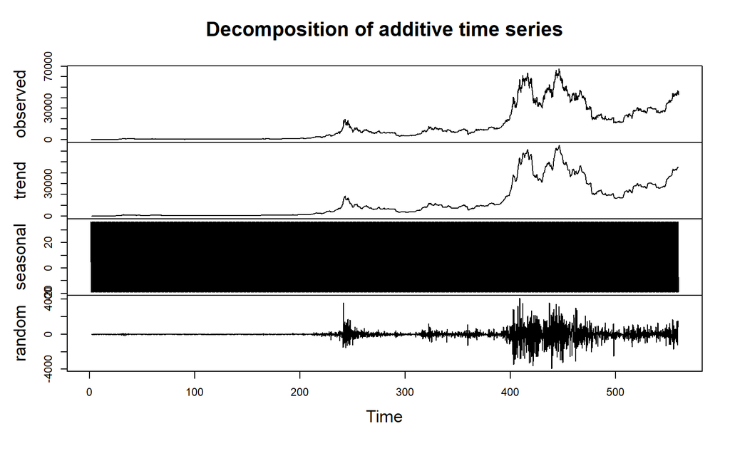

```r
BTCdailyts = ts(as.numeric(BTCdaily), frequency=7)
BTCdailytsdecomp = decompose(BTCdailyts)
plot(BTCdailytsdecomp)
```

### Day-of-Year Seasonality

A more common approach to seasonality is to model the time of the year to capture the impact of actual seasons. This can be done with the daily price series; however, since the regression model would output coefficients for all the 364 day dummy variables, we’ll just generate the time series decomposition plot. One additional parameter we can include in this case is indicating the starting point of the data. Since this is an annual cycle, the first numeric input is the starting year, and the 118 is derived from the first observation on April 28, which was the 118th day of year in 2013. *An important flaw here may be the handling of leap years. I’m not sure that the tseries package is correctly handling leap years when the frequency is set to 365. It is likely just modeling a 365-day cycle, so every leap year will shift the particular dates by 1.*

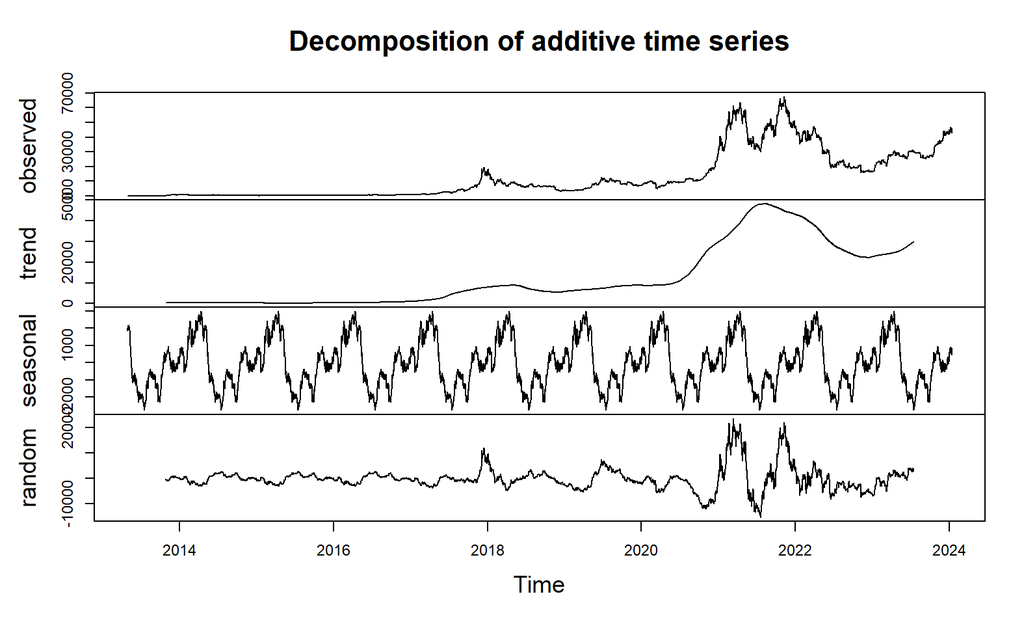

```r
BTCdayyearts = ts(as.numeric(BTCdaily), frequency=365, start=c(2013,118))
BTCdayyeartsdecomp = decompose(BTCdayyearts)
plot(BTCdayyeartsdecomp)
```

### Month-of-Year Seasonality

```r
rBTCmonth$count = 1:length(rBTCmonth$AnnRet)
rBTCmonth$month = (rBTCmonth$count+6) %% 12
monthreg = lm(AnnRet~as.factor(month),data=rBTCmonth)
summary(monthreg)
```

```
Call:
lm(formula = AnnRet ~ as.factor(month), data = rBTCmonth)

Residuals:
    Min      1Q  Median      3Q     Max
-698.58 -175.05    3.27  142.95 1823.74

Coefficients:
                   Estimate Std. Error t value Pr(>|t|)
(Intercept)         230.710     94.699   2.436   0.0163 *
as.factor(month)1    -2.229    133.925  -0.017   0.9867
as.factor(month)2  -189.689    133.925  -1.416   0.1593
as.factor(month)3  -273.812    133.925  -2.045   0.0431 *
as.factor(month)4  -160.072    137.233  -1.166   0.2458
as.factor(month)5  -285.569    137.233  -2.081   0.0396 *
as.factor(month)6  -129.082    137.233  -0.941   0.3488
as.factor(month)7  -160.416    133.925  -1.198   0.2334
as.factor(month)8  -236.112    133.925  -1.763   0.0805 .
as.factor(month)9  -151.530    133.925  -1.131   0.2602
as.factor(month)10 -231.405    133.925  -1.728   0.0867 .
as.factor(month)11 -309.794    133.925  -2.313   0.0225 *
---
Signif. codes:  0 ‘***’ 0.001 ‘**’ 0.01 ‘*’ 0.05 ‘.’ 0.1 ‘ ’ 1

Residual standard error: 314.1 on 117 degrees of freedom
Multiple R-squared:  0.09448,   Adjusted R-squared:  0.00935
F-statistic:  1.11 on 11 and 117 DF,  p-value: 0.3598
```

```r
monthreg2 = lm(AnnRet~as.factor(month),data=rBTCmonth[rBTCmonth$Date!=as.yearmon("Nov 2013"),])
summary(monthreg2)
```

```
Call:
lm(formula = AnnRet ~ as.factor(month), data = rBTCmonth[rBTCmonth$Date !=
    as.yearmon("Nov 2013"), ])

Residuals:
    Min      1Q  Median      3Q     Max
-557.40 -169.70   13.38  147.94  592.77

Coefficients:
                   Estimate Std. Error t value Pr(>|t|)
(Intercept)           230.7       78.6   2.935  0.00402 **
as.factor(month)1    -184.6      113.9  -1.621  0.10780
as.factor(month)2    -189.7      111.2  -1.706  0.09059 .
as.factor(month)3    -273.8      111.2  -2.463  0.01524 *
as.factor(month)4    -160.1      113.9  -1.405  0.16259
as.factor(month)5    -285.6      113.9  -2.507  0.01356 *
as.factor(month)6    -129.1      113.9  -1.133  0.25944
as.factor(month)7    -160.4      111.2  -1.443  0.15168
as.factor(month)8    -236.1      111.2  -2.124  0.03578 *
as.factor(month)9    -151.5      111.2  -1.363  0.17546
as.factor(month)10   -231.4      111.2  -2.082  0.03956 *
as.factor(month)11   -309.8      111.2  -2.787  0.00622 **
---
Signif. codes:  0 ‘***’ 0.001 ‘**’ 0.01 ‘*’ 0.05 ‘.’ 0.1 ‘ ’ 1

Residual standard error: 260.7 on 116 degrees of freedom
Multiple R-squared:  0.09599,   Adjusted R-squared:  0.01027
F-statistic:  1.12 on 11 and 116 DF,  p-value: 0.3523
```

Similar to daily series, the linear time trend is not significant.

```r
monthreg2 = lm(AnnRet~count+as.factor(month),data=rBTCmonth[rBTCmonth$Date!=as.yearmon("Nov 2013"),])
summary(monthreg2)
```

```
Call:
lm(formula = AnnRet ~ count + as.factor(month), data = rBTCmonth[rBTCmonth$Date !=
    as.yearmon("Nov 2013"), ])

Residuals:
   Min     1Q Median     3Q    Max
-567.3 -167.2   15.5  155.5  596.1

Coefficients:
                    Estimate Std. Error t value Pr(>|t|)
(Intercept)         212.5452    89.0629   2.386  0.01864 *
count                 0.2752     0.6267   0.439  0.66137
as.factor(month)1  -186.5298   114.3855  -1.631  0.10569
as.factor(month)2  -190.2396   111.5537  -1.705  0.09083 .
as.factor(month)3  -274.6373   111.5625  -2.462  0.01531 *
as.factor(month)4  -159.5217   114.3082  -1.396  0.16554
as.factor(month)5  -285.2940   114.3031  -2.496  0.01398 *
as.factor(month)6  -129.0825   114.3014  -1.129  0.26111
as.factor(month)7  -159.0398   111.5907  -1.425  0.15681
as.factor(month)8  -235.0107   111.5749  -2.106  0.03735 *
as.factor(month)9  -150.7046   111.5625  -1.351  0.17939
as.factor(month)10 -230.8547   111.5537  -2.069  0.04074 *
as.factor(month)11 -309.5183   111.5485  -2.775  0.00645 **
---
Signif. codes:  0 ‘***’ 0.001 ‘**’ 0.01 ‘*’ 0.05 ‘.’ 0.1 ‘ ’ 1

Residual standard error: 261.6 on 115 degrees of freedom
Multiple R-squared:  0.09751,   Adjusted R-squared:  0.003334
F-statistic: 1.035 on 12 and 115 DF,  p-value: 0.4217
```

Now let’s plot out the full time series decomposition of the monthly series. Since this is one of the more meaningful decompositions we’ll generate, the final three lines below will create a high-quality output of the plot in a pdf format.

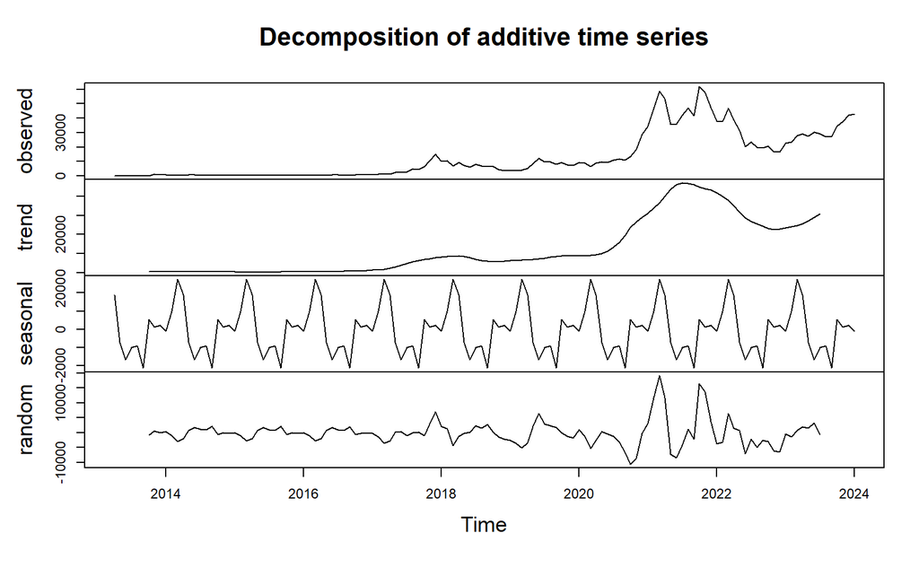

```r
BTCts_Close = ts(as.numeric(BTCmonth), frequency=12, start=c(2013,4))
BTCtsdecomp = decompose(BTCts_Close)
plot(BTCtsdecomp)
```

```r
# Create output pdf file for the plot, plot it, and save file.
# pdf("BTCtsdecomp_month_year.pdf", width=6)
# plot(BTCtsdecomp)
# dev.off()
```

### Bitcoin Halving Seasonality

One feature of the Bitcoin protocol is the reduction in block rewards that occurs every four years. Specifically, this fixed portion of mining rewards that are new bitcoins being mined into existence get reduced by 50% every 210,000 blocks. Since the mining process produces a new block every 10 minutes, this translates to roughly 4 years.

$1 halving = 210,000 blocks \cdot \dfrac{10min}{1block} \cdot \dfrac{1hr}{60min} \cdot \dfrac{1day}{24hr} = 1,458days+8hr = 208.\overline{33}weeks = 3.995years$

In addition to not exactly measuring 4 years, there is the additional variation around the 10 minute-per-block timing in the short-term. The Bitcoin protocol has a difficulty adjustment that takes effect every 2,016 blocks ($$14 days). This automatic adjustment allows the mining difficulty to adapt to changes in network hash rate without impacting the block timing, which enables Bitcoin’s algorithmic monetary inflation.

So there isn’t quite a clean way to split the halving timeline into perfect cycles at any of the frequencies. But we can round to the nearest whole number and see what we get with each.

#### Daily Halving Seasonality

The Bitcoin halving cycle is closest to 1,458 days, so lets examine the time series decomposition with that frequency. One clear observation is how the seasonal component now captures a large amount of the variation. Since we just added 1,457 dummy variables to the regression model, it is not surprising that absorbed much of the volatility. This is also why we don’t display the summary of the results. Then the lack of three full cycles leads to a flat period in the residual (random) and an abrupt jump in the seasonal fit. This is expected since some remainders (`dayhalf`) have only been observed twice in the data. As we approach the 2024 halving, these jumps are expected to smooth out. Then to help with the time conversion below is the conversion to the time label in the plot.

- 2012 Halving (Nov. 28, block 210,000): No price data yet
- 2016 Halving (July 9, block 420,000): `dayhalf`=1169 $\implies$ Time=1.80
- 2020 Halving (May 11, block 630,000): `dayhalf`=1113 $\implies$ Time=2.76
- 2024 Halving (?, block 840,000): `dayhalf`=1057? $\implies$ Time=3.72?

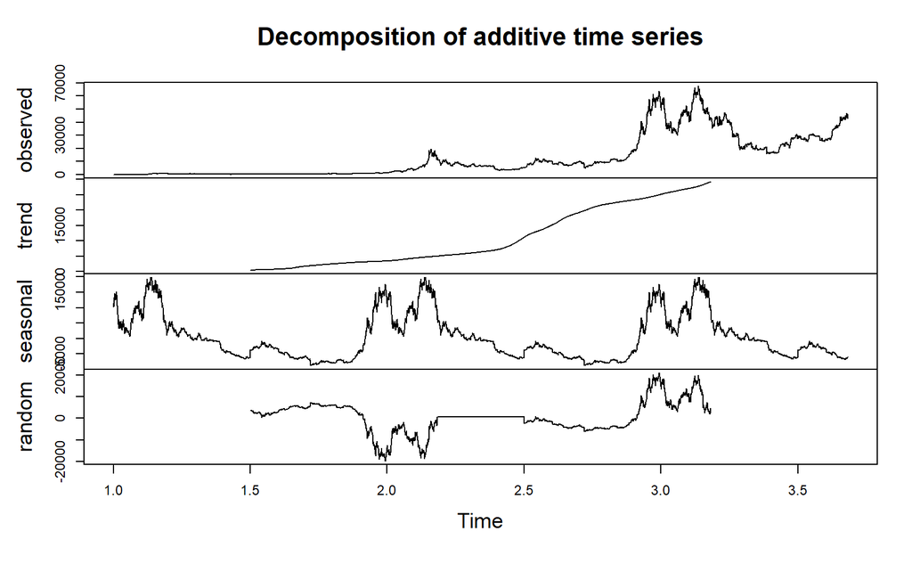

```r
rBTCdaily$dayhalf = rBTCdaily$count %% 1458
dailyhalfreg = lm(AnnRet~count+as.factor(dayhalf),data=rBTCdaily)
BTCdailyhalfts = ts(as.numeric(BTCdaily), frequency=1458)
BTCdailyhalftsdecomp = decompose(BTCdailyhalfts)
plot(BTCdailyhalftsdecomp)
```

#### Weekly Halving Seasonality

- 2012 Halving (Nov. 28, block 210,000): No price data yet
- 2016 Halving (July 9, block 420,000): `weekhalf`=168 $\implies$ Time=1.80
- 2020 Halving (May 11, block 630,000): `weekhalf`=161 $\implies$ Time=2.77
- 2024 Halving (?, block 840,000): `weekhalf`=154? $\implies$ Time=3.74?

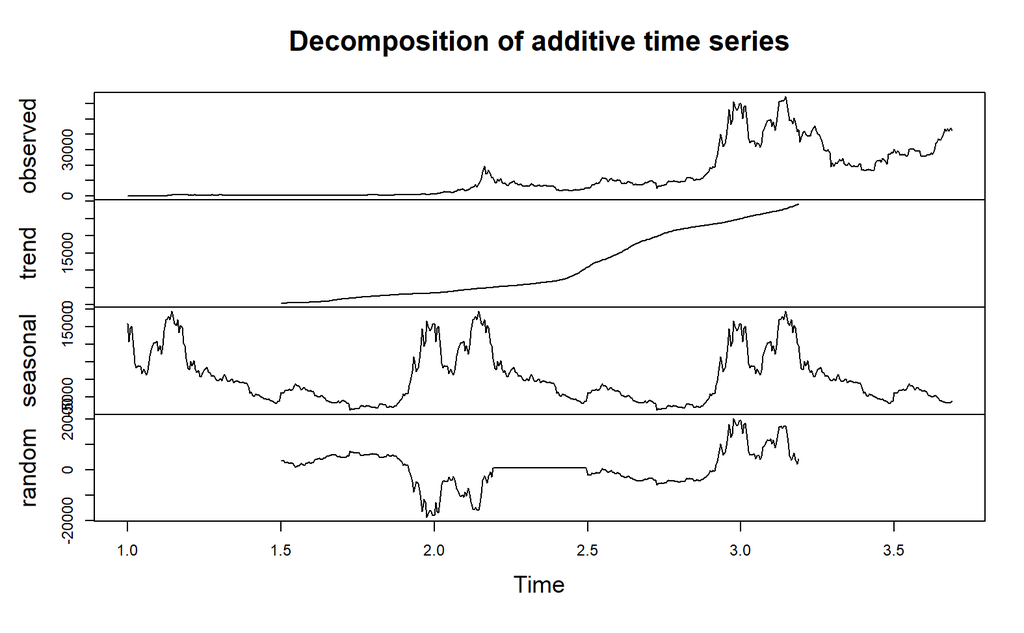

```r
rBTCweeks$count = 1:length(rBTCweeks$AnnRet)
rBTCweeks$weekhalf = rBTCweeks$count %% 208
weekshalfreg = lm(AnnRet~count+as.factor(weekhalf),data=rBTCweeks)
BTCweekshalfts = ts(as.numeric(BTCweeks), frequency=208)
BTCweekshalftsdecomp = decompose(BTCweekshalfts)
plot(BTCweekshalftsdecomp)
```